# Part II - Features and Characteristics of High Borrowing States

## by Fathma Yusuf Hussein

## Investigation Overview

> The main interest was in finding out the main features that are common in high borrowing states of loan listings. Specifically in terms of: BorrowerState, Occupation, IncomeRanges, MonthlyLoanPayment, Loan Terms, BorrowerRate and TotalProsperLoans.

## Dataset Overview

> The dataset consisted of 113937 loan listings with 81 sets of features which were majorly not used aside from the 7 mentioned features of interest. The data was broken down into subsets of high borrowing states and occupations so as to narrow down findings and have a look at the features more distinctively

## Distribution of the top 7 state with the highest borrower listings

The top 7 states with high number of borrower listings were found to be: CA, TX, NY, FL, IL, GA, OH

CA(California) State has the highest distribution out of the 7 high borrowing rate states by a large margin. This prompts more analysis on CA borrowers and their features as compared to the other top 7 states. These sates will be the main centres around the investigations that follow.

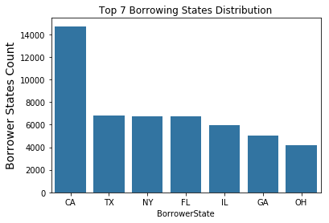

```python
ordered_states = loan_df1['BorrowerState'].value_counts().index
color1 = sb.color_palette()[0]

sb.countplot(data = loan_df1, x = 'BorrowerState', color = color1, order=ordered_states);
plt.title('Top 7 Borrowing States Distribution');
plt.ylabel('Borrower States Count', fontsize=14);
```

## Distribution of common loan terms listed by borrowers from the top 7 borrowing states

A Pie plot narrowed down the observation that the most common/popular loan term taken by borrowers from the 7 highest borrowing states is 36 months

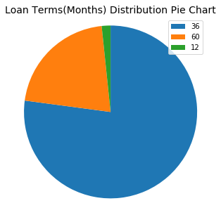

```python
#plot pie chart to show the general distribution of loan terms

sorted_terms = loan_df1['Term'].value_counts()
ordered_terms = loan_df1['Term'].value_counts().index

plt.figure(figsize=[20,5])
labels = ordered_terms

plt.pie(sorted_terms, startangle=90, counterclock=False);
plt.legend(labels, loc='best');
plt.axis('square');
plt.title('Loan Terms(Months) Distribution Pie Chart', fontsize=14);
```

## Distribution of monthly payments of the top 7 borrowing states

The distribution is more rightly skewed with the numbers of monthly payments reducing as the values of the payment increases. This meant that the higher the monthly payment was, the lower the number of people making payment.

The distribution also showed that the highest payments made monthly are between 150 to 200 US Dollars by borrowers from the top 7 borrowing states.

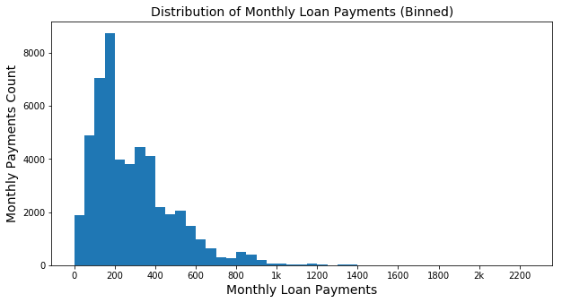

```python
# Plot histogram to show distribution of monthy loan payments made by borrowers fro top 7 borrowing states

bins3 = np.arange(0, loan_df1['MonthlyLoanPayment'].max()+50,50)
plt.figure(figsize=[10,5])

plt.hist(data = loan_df1, x = 'MonthlyLoanPayment', bins = bins3);
plt.xticks([0, 200, 400, 600, 800, 1000, 1200, 1400, 1600, 1800, 2000, 2200], [0, 200, 400, 600, 800, '1k', 1200, 1400, 1600, 1800, '2k', 2200]);
plt.title('Distribution of Monthly Loan Payments (Binned)', fontsize=14);
plt.xlabel('Monthly Loan Payments', fontsize=14);
plt.ylabel('Monthly Payments Count', fontsize=14);
```

## Relationship between monthly payments and income range categories of top 7 borrowing states

A facet grid of histograms showed that borrowers in the income range category of '25,000-49,999 US Dollars' managed to garner the highest number of monthly payment i.e. above 2500 made, highest of all the other income range categories. The lowest number of monthly payments made on the other hand was '0 US Dollars' and 'Not employed' category of borrowers.

From the plots, it further affirmed that the higher the monthly payment, the lower the number of payments made with all categories maintaining majority of monthly payments at between 0 to 1000 US Dollars i.e below 1000 US Dollars

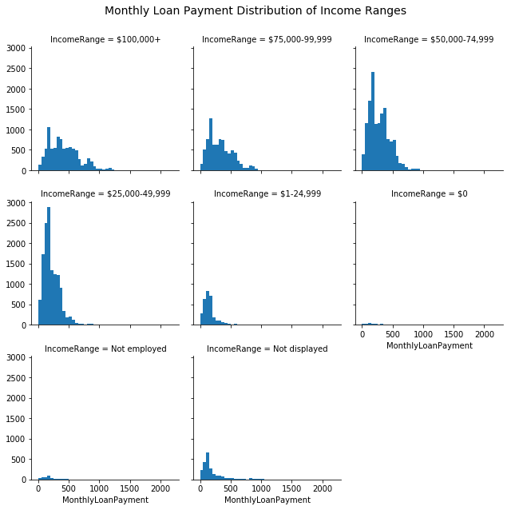

```python
#Plot facet grid to show case the distribution of monthly loan payments in the different income range categories

bins5 = np.arange(0, 2200+50, 50)

facet = sb.FacetGrid(data=loan_df1, col='IncomeRange', col_wrap=3);
facet.map(plt.hist, 'MonthlyLoanPayment', bins=bins5);

facet.fig.subplots_adjust(top=0.9);
facet.fig.suptitle('Monthly Loan Payment Distribution of Income Ranges', fontsize=14);
```

## Correlation between the borrower rate(i.e. loan interest rate) of borrowers within top 7 borrowing states and monthly payments

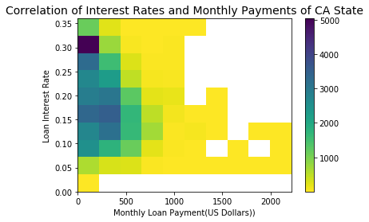

```python
#Plot heatmap to show correlation between monthly loan payments and borrowing rates of borrowers within CA state

plt.hist2d(data = loan_df1, x='MonthlyLoanPayment', y='BorrowerRate', cmin=0.3, cmap='viridis_r')
plt.colorbar()
plt.xlabel('Monthly Loan Payment(US Dollars))')
plt.ylabel('Loan Interest Rate');
plt.title('Correlation of Interest Rates and Monthly Payments of CA State', fontsize=14);
```

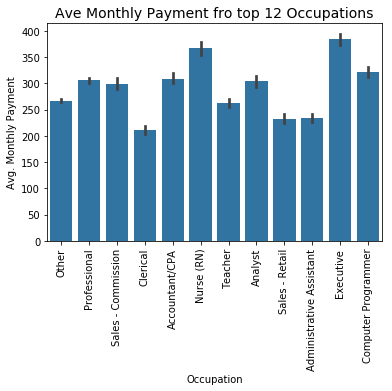

```python
#Plot barplots to visualize the relationship and trend between the top 12 occupations listed and monthly payments made in the top 7 borrowing states

sb.barplot(data = loan_df3, x='Occupation', y='MonthlyLoanPayment', color = color1);
plt.xticks(rotation=15);
plt.ylabel('Avg. Monthly Payment');
plt.xticks(rotation=90);
plt.title('Ave Monthly Payment fro top 12 Occupations', fontsize=14);
```

## Correlation of the interest rates of the loan terms of CA State borrowers according to their monthly payments

This was to narrow down on the correlation to the highest borrowing state as opposed to the top 7 states and affirm the observation and check in terms of loan terms taken as well

The 12 month term showcased in the plots shows is evenly distributed in the monthly payment scale but seems to be more concentrated in the lower interest rates as compared to the other higher loan terms

The 36 month terms is heavily distributed in mohtly payments below 1400 and has distribution across the interest rates with no concentration of specific rates in particular. From the plot, it is the most occuring term than any of the other terms selected by borrowers

The 60 month term seemed to be less in distribution like the 12 month term and had more concentration in monthly payments less than 1000 and borrowing rates between 5 and 35 percent

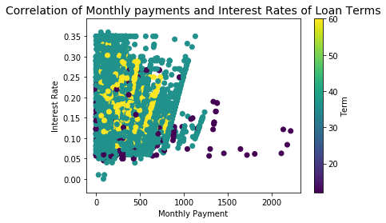

```python
# Plot color encoded scatter plot to showcase the distribution of loan terms in monthly payments and borrower interest rates

plt.scatter(data=ca_df, x='MonthlyLoanPayment',y='BorrowerRate', c = 'Term');
plt.colorbar(label = 'Term');
plt.xlabel('Monthly Payment');
plt.ylabel('Interest Rate');
plt.title('Correlation of Monthly payments and Interest Rates of Loan Terms', fontsize=14);
```

## Distribution of the top 3 borrowing states according to the top 12 occupations listed and the average monthly payments contributed

The comparison between the different occupation listings from the top 3 borrowing states vary and show that different occupations from different states have varying monthly payment averages.

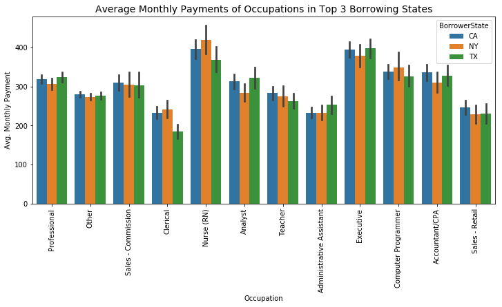

```python
#Plot bars to show the distribution of the top 3 borrowing states according to their occupation listings and average monthly payments
plt.figure(figsize = [12,5])

sb.barplot(data = loan_df3, x='Occupation', y='MonthlyLoanPayment', hue = 'BorrowerState');
plt.xticks(rotation=15);
plt.ylabel('Avg. Monthly Payment');
plt.xticks(rotation=90);
plt.title('Average Monthly Payments of Occupations in Top 3 Borrowing States', fontsize=14);
```